# Mini-project 3

Author

Kunal Ghosh, Alexandre Turgis

The response variable is `life_expectancy` (years, from Gapminder). The five new predictors are `isoecd`, `isopec`, `body_mass_index_bmi_men`, `body_mass_index_bmi_women` and `poverty`. The earlier predictors are sanitation access, food supply, murder rate, child deaths and female head of state.

## Libraries and data load

```r
library(tidyverse)
library(tidymodels)
library(glmnet)
library(rpart)
library(rpart.plot)
library(ranger)
library(vip)
library(ggrepel)
set.seed(3)
```

```r
gap <- read_csv("Data/project3_2025.csv") |>
  mutate(isoecd = factor(isoecd, labels = c("Not OECD", "OECD")),
         isopec = factor(isopec, labels = c("Not OPEC", "OPEC")))
glimpse(gap)
```

```
Rows: 194
Columns: 13
$ geo                             <chr> "afg", "ago", "alb", "and", "are", "ar…
$ name                            <chr> "Afghanistan", "Angola", "Albania", "A…
$ life_expectancy                 <dbl> 69.02, 64.70, 80.00, 84.20, 80.39, 77.…
$ sanitation_access_pct           <dbl> 54.49580, NA, 99.29972, 100.00000, 99.…
$ food_supply_kcal_per_person_day <dbl> 2243.49, 2434.79, 3390.48, NA, 3321.43…
$ murder_deaths_per_100k          <dbl> 5.1767956, 4.5019166, 3.0070272, 0.663…
$ child_deaths_per_100k           <dbl> 166.590218, 230.576102, 9.236849, 1.20…
$ female_hos_binary               <dbl> 0, 0, 0, 0, 0, NA, 0, 0, NA, NA, 0, NA…
$ isoecd                          <fct> Not OECD, Not OECD, Not OECD, Not OECD…
$ isopec                          <fct> Not OPEC, OPEC, Not OPEC, Not OPEC, No…
$ body_mass_index_bmi_men         <dbl> 22.3, 22.1, 27.0, 27.6, 28.3, 27.8, 25…
$ body_mass_index_bmi_women       <dbl> 23.7, 23.9, 26.5, 26.4, 29.3, 27.7, 27…
$ poverty                         <dbl> 46664.314849, 41710.117144, 151.217316…
```

```r
# Missing values per variable (only life_expectancy missing rows are dropped below)
colSums(is.na(gap))
```

```
                            geo                            name
                              0                               0
                life_expectancy           sanitation_access_pct
                              1                              17
food_supply_kcal_per_person_day          murder_deaths_per_100k
                             11                               1
          child_deaths_per_100k               female_hos_binary
                              1                              78
                         isoecd                          isopec
                              0                               0
        body_mass_index_bmi_men       body_mass_index_bmi_women
                              5                               5
                        poverty
                              9
```

## Exploratory data analysis

For this section we graph and summarize each of the 5 new predictors against life expectancy.

## Variable 1: OECD membership (`isoecd`)

### Graph and description

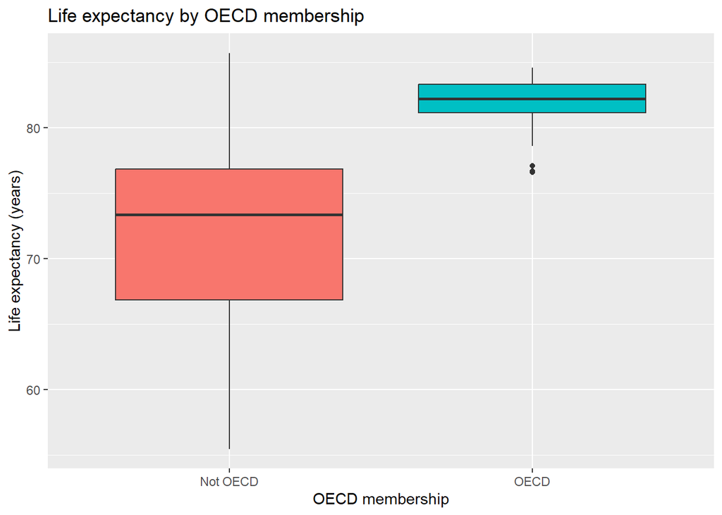

```r
gap |>
  filter(!is.na(life_expectancy)) |>
  ggplot(aes(x = isoecd, y = life_expectancy, fill = isoecd)) +
  geom_boxplot(show.legend = FALSE) +
  labs(title = "Life expectancy by OECD membership",
       x = "OECD membership", y = "Life expectancy (years)")
```

OECD countries have much higher life expectancy than non-members, and the spread is far smaller. Every OECD country is between about 77 and 85 years. Non-members range from about 55 to 86, so being a non-member tells us little by itself while being a member tells us a lot.

### Stats and description

```r
gap |>
  filter(!is.na(life_expectancy)) |>
  group_by(isoecd) |>
  summarize(n = n(), mean = mean(life_expectancy), median = median(life_expectancy),
            sd = sd(life_expectancy), min = min(life_expectancy), max = max(life_expectancy))
```

```
# A tibble: 2 × 7
  isoecd       n  mean median    sd   min   max
  <fct>    <int> <dbl>  <dbl> <dbl> <dbl> <dbl>
1 Not OECD   162  72.1   73.3  6.48  55.5  85.7
2 OECD        31  81.7   82.2  2.21  76.6  84.6
```

The 31 OECD countries average about 81.7 years (sd 2.2) and the 162 non-members average about 72.1 (sd 6.5), a gap of roughly 9.6 years. The point-biserial correlation with life expectancy is about 0.51. OECD membership is a categorical, wealth-related variable, so it will likely overlap with other predictors such as sanitation and child deaths. It does not need to be logged.

## Variable 2: OPEC membership (`isopec`)

### Graph and description

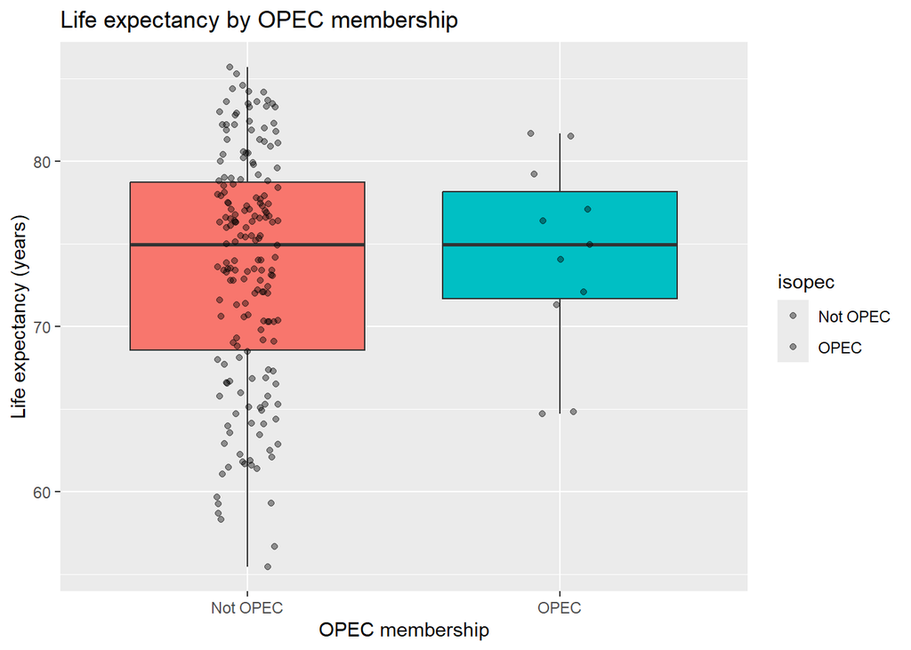

```r
gap |>
  filter(!is.na(life_expectancy)) |>
  ggplot(aes(x = isopec, y = life_expectancy, fill = isopec)) +
  geom_boxplot(show.legend = FALSE) +
  geom_jitter(width = 0.1, alpha = 0.4) +
  labs(title = "Life expectancy by OPEC membership",
       x = "OPEC membership", y = "Life expectancy (years)")
```

The two boxes sit at nearly the same height, so OPEC membership does not separate life expectancy. OPEC countries vary a lot: Angola and Nigeria are near 65 years while Kuwait and Qatar are above 81.

### Stats and description

```r
gap |>
  filter(!is.na(life_expectancy)) |>
  group_by(isopec) |>
  summarize(n = n(), mean = mean(life_expectancy), median = median(life_expectancy), sd = sd(life_expectancy))
```

```
# A tibble: 2 × 5
  isopec       n  mean median    sd
  <fct>    <int> <dbl>  <dbl> <dbl>
1 Not OPEC   182  73.6   75.0  7.04
2 OPEC        11  74.4   75.0  5.82
```

The 11 OPEC countries average about 74.4 years and the 182 others about 73.6, a difference under one year, and the correlation is about 0.03. Because only 11 countries are members, the group mean is also noisy. I expect OPEC membership to be a weak predictor and the models should drop it.

## Variable 3: Men’s BMI (`body_mass_index_bmi_men`)

### Graph and description

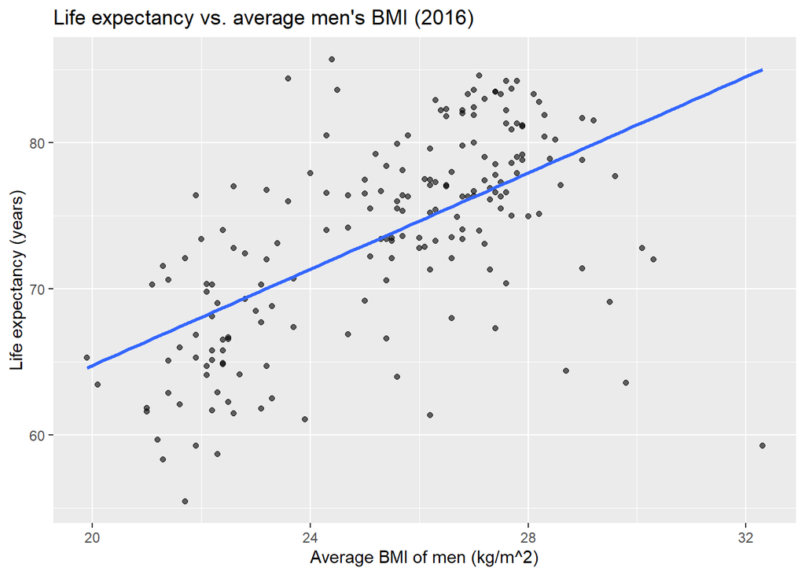

```r
gap |>
  filter(!is.na(life_expectancy), !is.na(body_mass_index_bmi_men)) |>
  ggplot(aes(x = body_mass_index_bmi_men, y = life_expectancy)) +
  geom_point(alpha = 0.6) +
  geom_smooth(method = "lm", se = FALSE) +
  labs(title = "Life expectancy vs. average men's BMI (2016)",
       x = "Average BMI of men (kg/m^2)", y = "Life expectancy (years)")
```

There is a moderately strong positive, roughly linear relationship: countries where men have a higher average BMI have higher life expectancy. In this range BMI is mostly a proxy for food availability and wealth, not a health benefit of weight itself. A few Pacific island nations have very high BMI with only middling life expectancy, which flattens the top of the trend.

### Stats and description

```r
gap |>
  select(life_expectancy, body_mass_index_bmi_men) |>
  drop_na() |>
  summarize(n = n(), correlation = cor(life_expectancy, body_mass_index_bmi_men))
```

```
# A tibble: 1 × 2
      n correlation
  <int>       <dbl>
1   189       0.593
```

```r
gap |>
  filter(!is.na(body_mass_index_bmi_men)) |>
  arrange(desc(body_mass_index_bmi_men)) |>
  select(name, body_mass_index_bmi_men, life_expectancy) |> head(5)
```

```
# A tibble: 5 × 3
  name      body_mass_index_bmi_men life_expectancy
  <chr>                       <dbl>           <dbl>
1 Nauru                        32.3            59.3
2 Tonga                        30.3            72
3 Samoa                        30.1            72.8
4 Tuvalu                       29.8            63.6
5 St. Lucia                    29.6            77.7
```

```r
gap |>
  filter(!is.na(body_mass_index_bmi_men)) |>
  arrange(body_mass_index_bmi_men) |>
  select(name, body_mass_index_bmi_men, life_expectancy) |> head(5)
```

```
# A tibble: 5 × 3
  name             body_mass_index_bmi_men life_expectancy
  <chr>                              <dbl>           <dbl>
1 Ethiopia                            19.9            65.3
2 Eritrea                             20.1            63.4
3 Congo, Dem. Rep.                    21              61.6
4 Zambia                              21              61.9
5 Timor-Leste                         21.1            70.3
```

The correlation is about 0.59 (189 countries). The highest men’s BMI values are Nauru (32.3), Tonga (30.3), Samoa (30.1) and Tuvalu (29.8), all small Pacific nations. The lowest are Ethiopia (19.9), Eritrea (20.1) and the Democratic Republic of the Congo (21.0). The variable is nearly symmetric (skewness about -0.2), so logging is not needed.

## Variable 4: Women’s BMI (`body_mass_index_bmi_women`)

### Graph and description

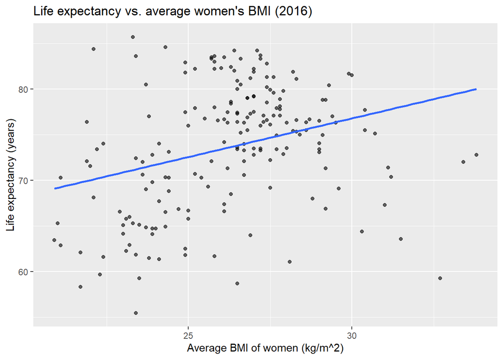

```r
gap |>
  filter(!is.na(life_expectancy), !is.na(body_mass_index_bmi_women)) |>
  ggplot(aes(x = body_mass_index_bmi_women, y = life_expectancy)) +
  geom_point(alpha = 0.6) +
  geom_smooth(method = "lm", se = FALSE) +
  labs(title = "Life expectancy vs. average women's BMI (2016)",
       x = "Average BMI of women (kg/m^2)", y = "Life expectancy (years)")
```

The relationship is positive but weaker and more scattered than for men. Many countries with women’s BMI between 25 and 30 have life expectancies anywhere from the mid 60s to the mid 80s.

### Stats and description

```r
gap |>
  select(life_expectancy, body_mass_index_bmi_women, body_mass_index_bmi_men) |>
  drop_na() |>
  summarize(cor_women_life = cor(life_expectancy, body_mass_index_bmi_women),
            cor_men_women = cor(body_mass_index_bmi_men, body_mass_index_bmi_women))
```

```
# A tibble: 1 × 2
  cor_women_life cor_men_women
           <dbl>         <dbl>
1          0.305         0.841
```

The correlation with life expectancy is about 0.30, noticeably lower than for men (0.59). Men’s and women’s BMI are likely highly correlated with each other, so a model may not need both. Women’s BMI is close to symmetric (skewness about 0.15), so it is not logged. Of the two BMI variables, men’s BMI is the better predictor on its own.

## Variable 5: Poverty (`poverty`)

### Graph and description

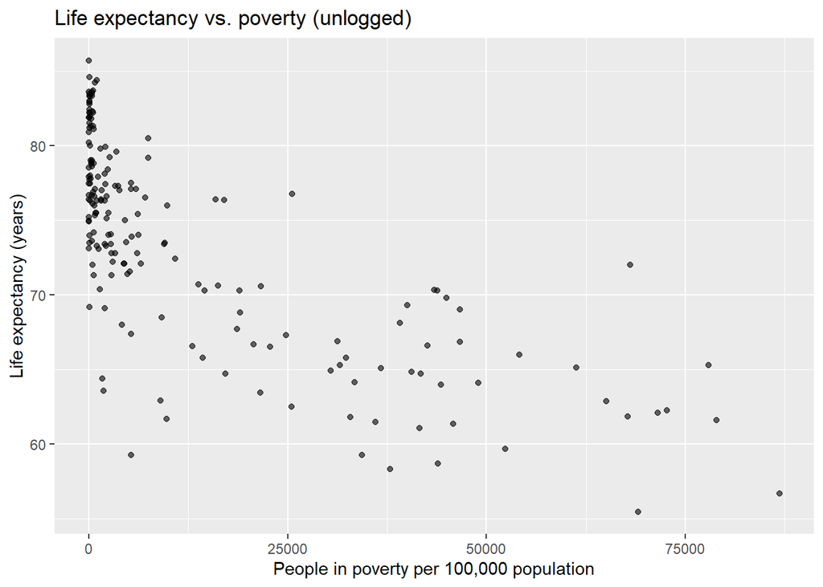

```r
gap |>
  filter(!is.na(life_expectancy), !is.na(poverty)) |>
  ggplot(aes(x = poverty, y = life_expectancy)) +
  geom_point(alpha = 0.6) +
  labs(title = "Life expectancy vs. poverty (unlogged)",
       x = "People in poverty per 100,000 population", y = "Life expectancy (years)")
```

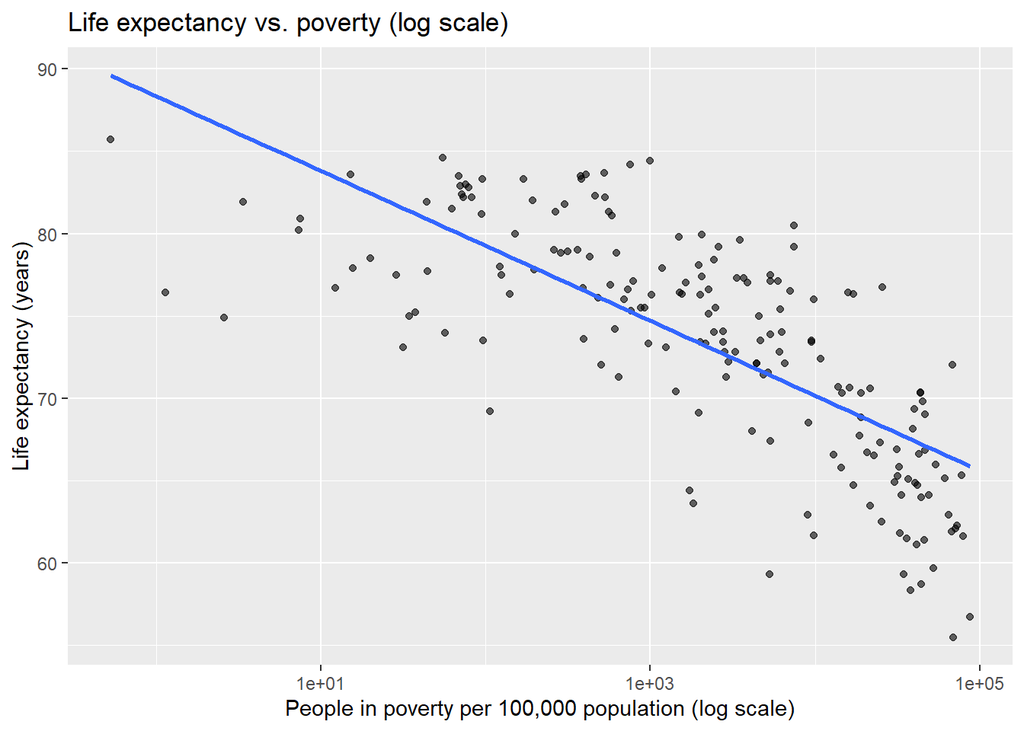

```r
gap |>
  filter(!is.na(life_expectancy), !is.na(poverty)) |>
  ggplot(aes(x = poverty, y = life_expectancy)) +
  geom_point(alpha = 0.6) +
  geom_smooth(method = "lm", se = FALSE) +
  scale_x_log10() +
  labs(title = "Life expectancy vs. poverty (log scale)",
       x = "People in poverty per 100,000 population (log scale)", y = "Life expectancy (years)")
```

On the raw scale most countries are bunched near zero with a few very high values, which makes the pattern hard to see. On the log scale the points spread out into a clear, fairly linear negative trend: more poverty goes with lower life expectancy.

### Stats and description

```r
gap |>
  select(name, life_expectancy, poverty) |>
  drop_na() |>
  summarize(n = n(), cor_raw = cor(life_expectancy, poverty),
            cor_log = cor(life_expectancy, log(poverty)),
            skew_raw = mean((poverty - mean(poverty))^3) / sd(poverty)^3,
            skew_log = mean((log(poverty) - mean(log(poverty)))^3) / sd(log(poverty))^3)
```

```
# A tibble: 1 × 5
      n cor_raw cor_log skew_raw skew_log
  <int>   <dbl>   <dbl>    <dbl>    <dbl>
1   184  -0.734  -0.736     1.72   -0.627
```

```r
gap |> arrange(desc(poverty)) |> select(name, poverty, life_expectancy) |> head(5)
```

```
# A tibble: 5 × 3
  name             poverty life_expectancy
  <chr>              <dbl>           <dbl>
1 South Sudan       86810.            56.7
2 Congo, Dem. Rep.  78911.            61.6
3 Mozambique        77915.            65.3
4 Malawi            72703.            62.3
5 Burundi           71543.            62.1
```

```r
gap |> arrange(poverty) |> select(name, poverty, life_expectancy) |> head(5)
```

```
# A tibble: 5 × 3
  name           poverty life_expectancy
  <chr>            <dbl>           <dbl>
1 Singapore        0.528            85.7
2 Algeria          1.14             76.4
3 Belarus          2.58             74.9
4 Slovenia         3.35             81.9
5 Czech Republic   7.37             80.2
```

The correlation is about -0.73 (184 countries), one of the strongest of the new variables. The most extreme countries are South Sudan, the Democratic Republic of the Congo, Mozambique, Malawi and Burundi, all with over 70,000 people in poverty per 100,000 and life expectancy of 57 to 65 years. The lowest values are Singapore, Algeria, Belarus and Slovenia. Poverty is strongly right skewed (skewness about 1.7) and becomes close to symmetric after logging (about -0.6), although the correlation barely changes (-0.74 logged). Poverty is missing for 9 countries including China, Qatar and Monaco.

## Which variable for logging?

Poverty needs to be logged. Its raw distribution is heavily right skewed with a handful of very large values, and the log scale makes the relationship with life expectancy cleaner. The other new predictors are either binary (`isoecd`, `isopec`) or roughly symmetric (men’s and women’s BMI), so they do not need logging. Among the earlier predictors, child deaths and murder rate are also right skewed, so I log them too. (Add 1 before logging if any value is 0.)

## Logging predictor variables and splitting data

Poverty, child deaths and murder rate are logged. Rows with no life expectancy are dropped, since we cannot train or test without the response. The remaining missing predictor values are filled with the training median inside the recipe so we do not lose most of the countries, especially since `female_hos_binary` is missing for 78 countries.

```r
gap2 <- gap |>
  filter(!is.na(life_expectancy)) |>
  mutate(log_poverty = log(poverty),
         log_child_deaths = log(child_deaths_per_100k),
         log_murder = log(murder_deaths_per_100k)) |>
  select(-geo, -name, -poverty, -child_deaths_per_100k, -murder_deaths_per_100k)

split <- initial_split(gap2, prop = 0.8)
train <- training(split)
test  <- testing(split)
c(train = nrow(train), test = nrow(test))
```

```
train  test
  154    39
```

```r
# which variables go into the models
rec <- recipe(life_expectancy ~ ., data = train) |>
  step_impute_median(all_numeric_predictors()) |>
  step_dummy(all_nominal_predictors()) |>
  step_normalize(all_numeric_predictors())
```

## Lasso regression

### Making model

The penalty is chosen with 10-fold cross-validation on the training data.

```r
folds <- vfold_cv(train, v = 10)
lasso_spec <- linear_reg(penalty = tune(), mixture = 1) |> set_engine("glmnet")
lasso_wf <- workflow() |> add_recipe(rec) |> add_model(lasso_spec)

lasso_tune <- tune_grid(lasso_wf, resamples = folds,
                        grid = grid_regular(penalty(range = c(-3, 0.5)), levels = 40),
                        metrics = metric_set(rmse, rsq))
```

[output not shown]

```
There were issues with some computations   A: x1
There were issues with some computations   A: x1
```

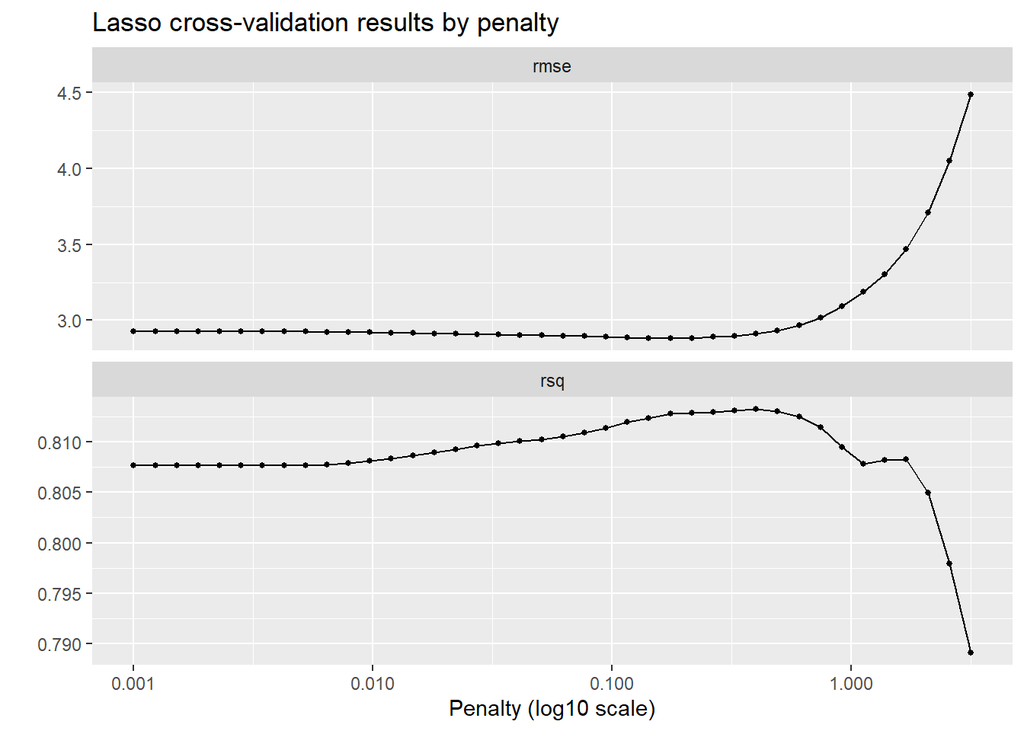

```r
autoplot(lasso_tune) +
  labs(title = "Lasso cross-validation results by penalty", x = "Penalty (log10 scale)")
```

```r
best_pen <- select_best(lasso_tune, metric = "rmse")
best_pen
```

```
# A tibble: 1 × 2
  penalty .config
    <dbl> <chr>
1   0.175 pre0_mod26_post0
```

```r
lasso_fit <- finalize_workflow(lasso_wf, best_pen) |> fit(train)
```

### Which variables

```r
lasso_coefs <- lasso_fit |> extract_fit_parsnip() |> tidy() |> filter(term != "(Intercept)")
lasso_coefs |> arrange(desc(abs(estimate)))
```

```
# A tibble: 10 × 3
   term                            estimate penalty
   <chr>                              <dbl>   <dbl>
 1 log_child_deaths                -4.22      0.175
 2 sanitation_access_pct            1.59      0.175
 3 log_murder                      -0.689     0.175
 4 log_poverty                     -0.438     0.175
 5 isopec_OPEC                      0.119     0.175
 6 isoecd_OECD                      0.0156    0.175
 7 food_supply_kcal_per_person_day  0.00378   0.175
 8 female_hos_binary                0         0.175
 9 body_mass_index_bmi_men          0         0.175
10 body_mass_index_bmi_women        0         0.175
```

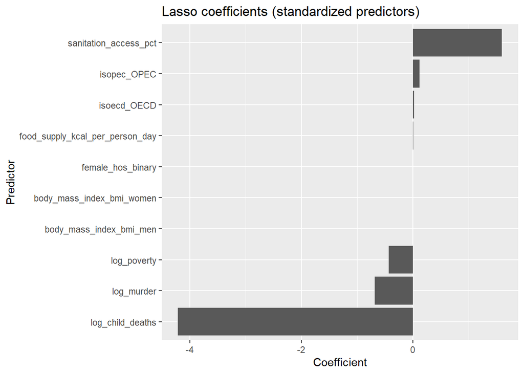

```r
lasso_coefs |>
  ggplot(aes(x = reorder(term, estimate), y = estimate)) +
  geom_col() + coord_flip() +
  labs(title = "Lasso coefficients (standardized predictors)",
       x = "Predictor", y = "Coefficient")
```

### Model evaluation-regression metrics on testing.

```r
metrics_set <- metric_set(rmse, rsq, mae)
lasso_res <- predict(lasso_fit, test) |> bind_cols(test) |>
  metrics_set(truth = life_expectancy, estimate = .pred)
lasso_res
```

```
# A tibble: 3 × 3
  .metric .estimator .estimate
  <chr>   <chr>          <dbl>
1 rmse    standard       3.48
2 rsq     standard       0.739
3 mae     standard       2.67
```

## Regression Tree

### Making model

```r
tree_spec <- decision_tree(cost_complexity = tune(), tree_depth = tune(), min_n = 5) |>
  set_engine("rpart") |> set_mode("regression")
tree_wf <- workflow() |> add_recipe(rec) |> add_model(tree_spec)

tree_tune <- tune_grid(tree_wf, resamples = folds,
                       grid = grid_regular(cost_complexity(), tree_depth(range = c(2, 6)), levels = 5),
                       metrics = metric_set(rmse, rsq))
```

[output not shown]

```
There were issues with some computations   A: x1
There were issues with some computations   A: x1
```

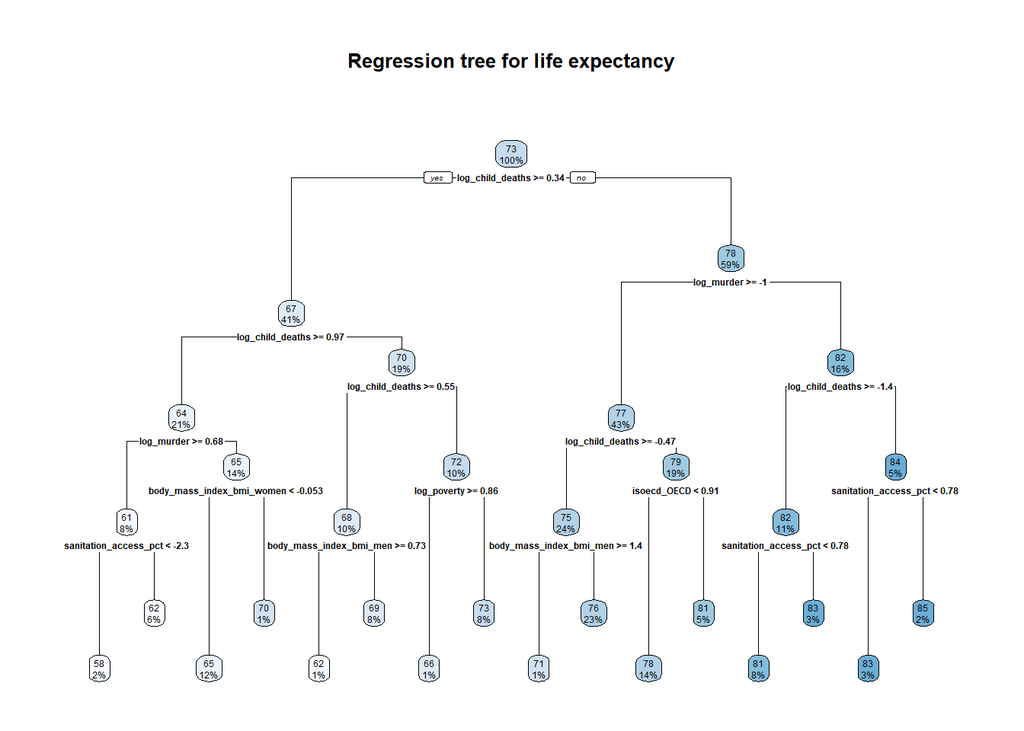

```r
best_tree <- select_best(tree_tune, metric = "rmse")
tree_fit <- finalize_workflow(tree_wf, best_tree) |> fit(train)

tree_fit |> extract_fit_engine() |>
  rpart.plot(roundint = FALSE, main = "Regression tree for life expectancy")
```

### Which variables

```r
tree_fit |> extract_fit_engine() |> pluck("variable.importance") |> sort(decreasing = TRUE)
```

```
               log_child_deaths                     log_poverty
                      6305.2348                       4539.8311
          sanitation_access_pct         body_mass_index_bmi_men
                      4241.4652                       3778.5964
food_supply_kcal_per_person_day       body_mass_index_bmi_women
                      2836.5960                       2772.9487
                     log_murder                     isoecd_OECD
                       769.3579                        176.2835
```

The variables that appear as splits in the tree are the ones the tree considers useful. Variables near the top of the tree separate countries best.

### Model evaluation-regression metrics on testing.

```r
tree_res_test <- predict(tree_fit, test) |> bind_cols(test) |>
  metrics_set(truth = life_expectancy, estimate = .pred) |> mutate(set = "test")
tree_res_train <- predict(tree_fit, train) |> bind_cols(train) |>
  metrics_set(truth = life_expectancy, estimate = .pred) |> mutate(set = "train")
bind_rows(tree_res_train, tree_res_test)
```

```
# A tibble: 6 × 4
  .metric .estimator .estimate set
  <chr>   <chr>          <dbl> <chr>
1 rmse    standard       1.89  train
2 rsq     standard       0.928 train
3 mae     standard       1.51  train
4 rmse    standard       4.27  test
5 rsq     standard       0.670 test
6 mae     standard       3.07  test
```

Comparing the training and testing rows checks for overfitting: a tree that is much better on training than on testing is overfit.

## Random forest

### Making model

```r
rf_spec <- rand_forest(trees = 500, mtry = tune(), min_n = tune()) |>
  set_engine("ranger", importance = "permutation") |> set_mode("regression")
rf_wf <- workflow() |> add_recipe(rec) |> add_model(rf_spec)

rf_tune <- tune_grid(rf_wf, resamples = folds, grid = 12,
                     metrics = metric_set(rmse, rsq))
```

```
i Creating pre-processing data to finalize 1 unknown parameter: "mtry"
```

[output not shown]

```
There were issues with some computations   A: x1
There were issues with some computations   A: x1
```

```r
best_rf <- select_best(rf_tune, metric = "rmse")
rf_fit <- finalize_workflow(rf_wf, best_rf) |> fit(train)
best_rf
```

```
# A tibble: 1 × 3
   mtry min_n .config
  <int> <int> <chr>
1     7    22 pre0_mod09_post0
```

### Which variables

[figure not shown]

```r
rf_fit |> extract_fit_parsnip() |>
  vip(num_features = 12) +
  labs(title = "Random forest variable importance (permutation)",
       x = "Predictor", y = "Importance")
```

### Model evaluation-regression metrics on testing.

```r
rf_res <- predict(rf_fit, test) |> bind_cols(test) |>
  metrics_set(truth = life_expectancy, estimate = .pred)
rf_res
```

```
# A tibble: 3 × 3
  .metric .estimator .estimate
  <chr>   <chr>          <dbl>
1 rmse    standard       3.84
2 rsq     standard       0.698
3 mae     standard       2.95
```

The forest’s out-of-bag error can also be used to check quality, but the testing metrics are the fairest comparison since the test set was never used for tuning.

## Variable selection comparison

```r
bind_rows(
  mutate(lasso_res, model = "Lasso"),
  mutate(tree_res_test, model = "Regression tree") |> select(-set),
  mutate(rf_res, model = "Random forest")
) |>
  select(model, .metric, .estimate) |>
  pivot_wider(names_from = .metric, values_from = .estimate)
```

```
# A tibble: 3 × 4
  model            rmse   rsq   mae
  <chr>           <dbl> <dbl> <dbl>
1 Lasso            3.48 0.739  2.67
2 Regression tree  4.27 0.670  3.07
3 Random forest    3.84 0.698  2.95
```

## Best model

Comparing with the table above. The model with the lowest test RMSE and MAE and highest R-squared is the best predictor. Random forests usually win on accuracy but are the hardest to interpret, the lasso is a single linear equation that is easy to explain, and a tree is the easiest to draw but usually has the highest error. If the lasso is within a small margin of the forest, I would recommend it for interpretability.

**Question:** Is the relationship between poverty and life expectancy different for OECD and non-OECD countries?

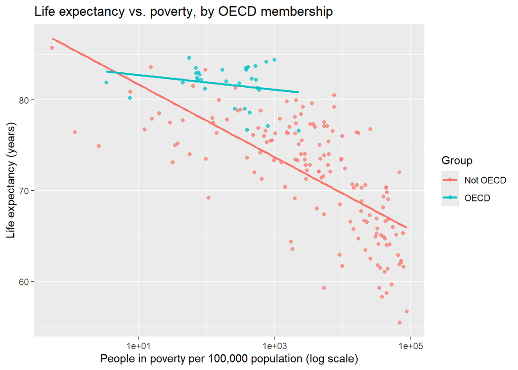

```r
gap |>
  filter(!is.na(life_expectancy), !is.na(poverty)) |>
  ggplot(aes(x = poverty, y = life_expectancy, color = isoecd)) +
  geom_point(alpha = 0.7) +
  geom_smooth(method = "lm", se = FALSE) +
  scale_x_log10() +
  labs(title = "Life expectancy vs. poverty, by OECD membership",
       x = "People in poverty per 100,000 population (log scale)",
       y = "Life expectancy (years)", color = "Group")
```